# RLC Quality Check Report and Weighting Production

[figure not shown]

## Introduction

Along this HTML document, you will find in the output/ folder an excel file.

In case you don’t find this file, this means that there was some issues during the execution of the script. However, I am pretty sure if the script give a success message, this means that a file should also be included there.

#### Before using the final outputted weight in the file, please make sure that you check all the tabs of this quality check report and confirm a successful methodology implementation.

### What to find in this output

In this output you will find the following tabs:

- **ID MATCHING**: *Check Cluster_ID between sampling and rlc data are matching*
- **Clusters inside Area**: *Check Clusters are inside the sampling area (50m threshold)*
- **Clusters follow RLC sampling**: *Check assessed clusters are random and follow the sampling (50m threshold)*
- **HHs inside sampling area**: *Check assessed HHs are inside the sampling are (50m threshold)*
- **Distance HHs to clusters**: *Check the distance between the assessed HHs and the sampled cluster points (50m threshold)*
- **Duplicated clusters/HHs**: *Check duplication between clusters and check if clusters share same HHs.*
- **Household Density**: *Calculate HH Density & Cluster Weights*
- **IDW**: *Spatial Interpolation using Inverse Distance Weighing (IDW)*
- **Estimation of Population**: *Estimate Population of Sampled Area. (Under Revision)*

### Feedback

Feedback on improvements to this product can be done through reaching out to:

- impact.geneva.phu@impact-initiatives.org
- abraham.azar@impact-initiatives.org or

## ID MATCHING

```
## All your clusters from the sampling frame are identical to the ones in the rlc data!!!
##
##
##
## All your clusters have a total of 3 HHs.
```

## Cluster inside Area

### Locations of each assessed cluster.

```
## All your cluster points are located inside the sampling area.
```

[interactive chart not shown]

### HeatMap of the assessed cluster.

```
## All your cluster points are located inside the sampling area.
##
## Generating the map:.
##
##
```

[interactive chart not shown]

## Clusters follow RLC sampling

This part is checking if the field team did follow the Sampling methodology and assessed the right locations.

```
## All your waypoints are close to the generated cluster points.
```

In case any point is was not in the 50 m buffer, a map will be generated below to show the difference.

## HHs inside sampling area

```
## All your hh points are located inside the sampling area.
```

[interactive chart not shown]

## Distance HHs to clusters

```
## All your hh points are close to the waypoints.
```

[interactive chart not shown]

## Duplicated clusters and HHs

```
## Attention:
##
## The following clusters have their buffer zone intersecting
## but none of the hh are sharing clusters
##
##
## |   |intersecting  |clusters      |
## |:--|:-------------|:-------------|
## |V1 |cluster_9222f |cluster_457a3 |
## |V2 |cluster_b9002 |cluster_49653 |
## |V3 |cluster_9222f |cluster_fedf9 |
```

[interactive chart not shown]

## Household Density

### Table of household density and weights

```
## Here is the generated weights table.
##
## |cluster_ID    | hhd_cluster|    weight|
## |:-------------|-----------:|---------:|
## |cluster_7444f |   0.0013370| 0.9556584|
## |cluster_3d8f9 |   0.0004758| 0.3401109|
## |cluster_ceb64 |   0.0021684| 1.5499443|
## |cluster_c12ff |   0.0005470| 0.3909887|
## |cluster_21915 |   0.0022594| 1.6150197|
## |cluster_dd5c9 |   0.0011033| 0.7886308|
## |cluster_60a4e |   0.0003863| 0.2761309|
## |cluster_9222f |   0.0004222| 0.3018055|
## |cluster_457a3 |   0.0007751| 0.5540624|
## |cluster_293dc |   0.0008342| 0.5962843|
## |cluster_b9002 |   0.0004028| 0.2879483|
## |cluster_25820 |   0.0006098| 0.4358719|
## |cluster_ec4e8 |   0.0019823| 1.4169029|
## |cluster_49653 |   0.0006299| 0.4502758|
## |cluster_73383 |   0.0012727| 0.9096799|
## |cluster_fedf9 |   0.0018749| 1.3401274|
## |cluster_f1cf7 |   0.0027098| 1.9369152|
## |cluster_b5d9f |   0.0056175| 4.0152907|
## |cluster_eadc1 |   0.0008132| 0.5812592|
## |cluster_dfc56 |   0.0017587| 1.2570928|
```

## IDW

Inverse distance weighted (IDW) interpolation determines cell values using a linearly weighted combination of a set of sample points. The weight is a function of inverse distance. The surface being interpolated should be that of a locationally dependent variable. This method assumes that the variable being mapped decreases in influence with distance from its sampled location.

- Reference: [ArcGIS](https://pro.arcgis.com/en/pro-app/latest/tool-reference/3d-analyst/how-idw-works.htm#:~:text=The%20Power%20parameter%20lets%20you,put%20on%20the%20nearest%20points.)

**Please note:** The Power parameter lets you control the significance of known points on the interpolated values based on their distance from the output point. It is a positive, real number, and its default value is 2. By defining a higher power value, more emphasis can be put on the nearest points.

[output not shown]

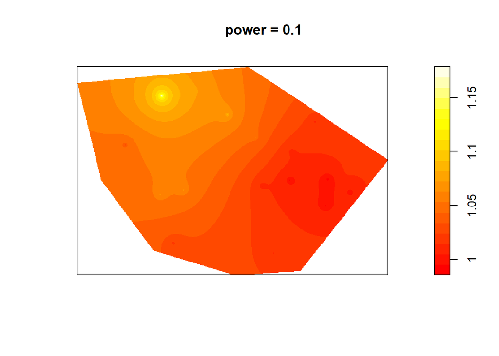

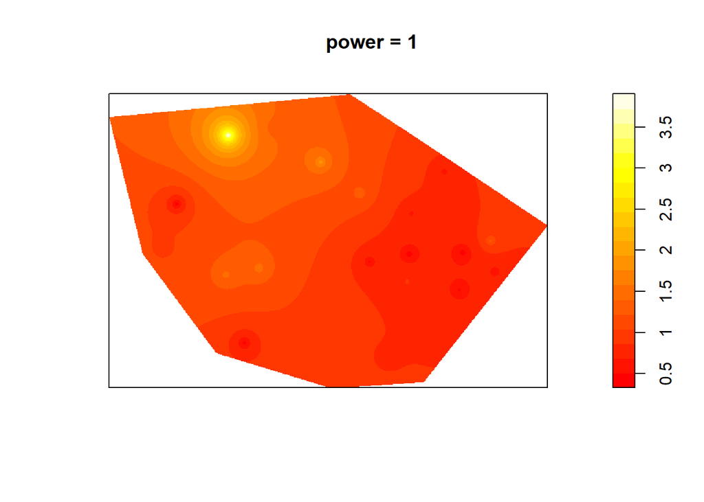

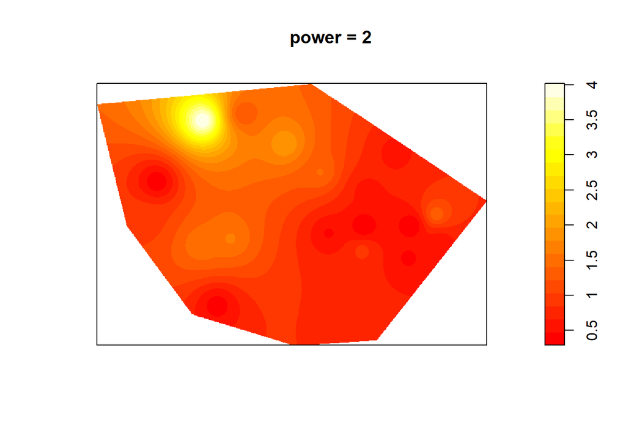

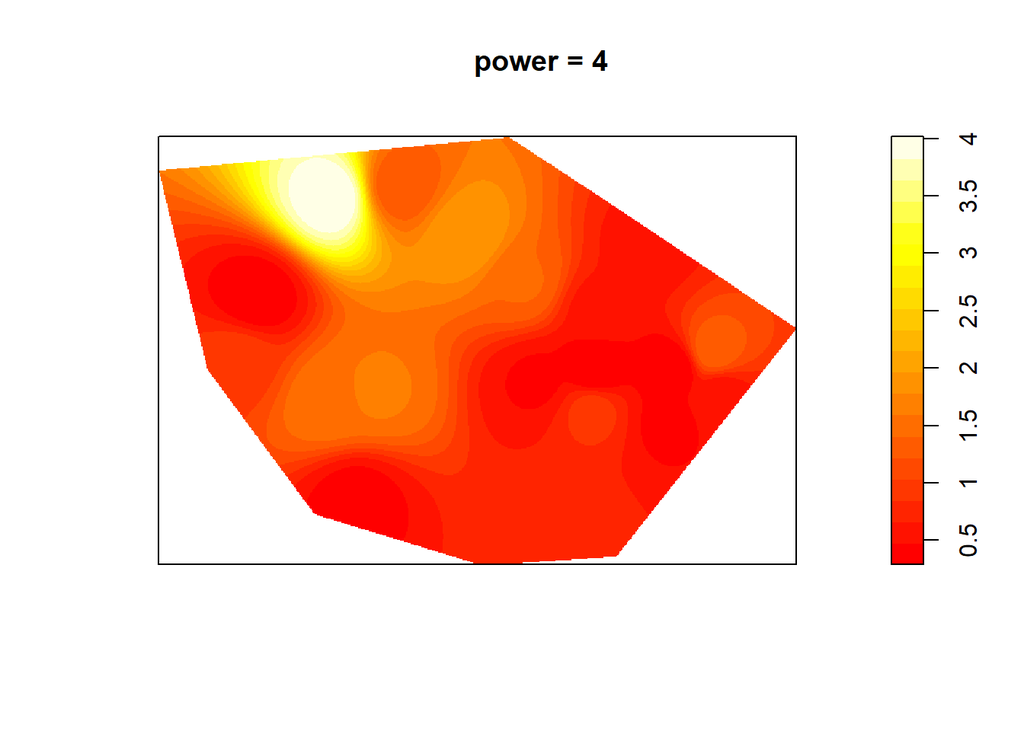

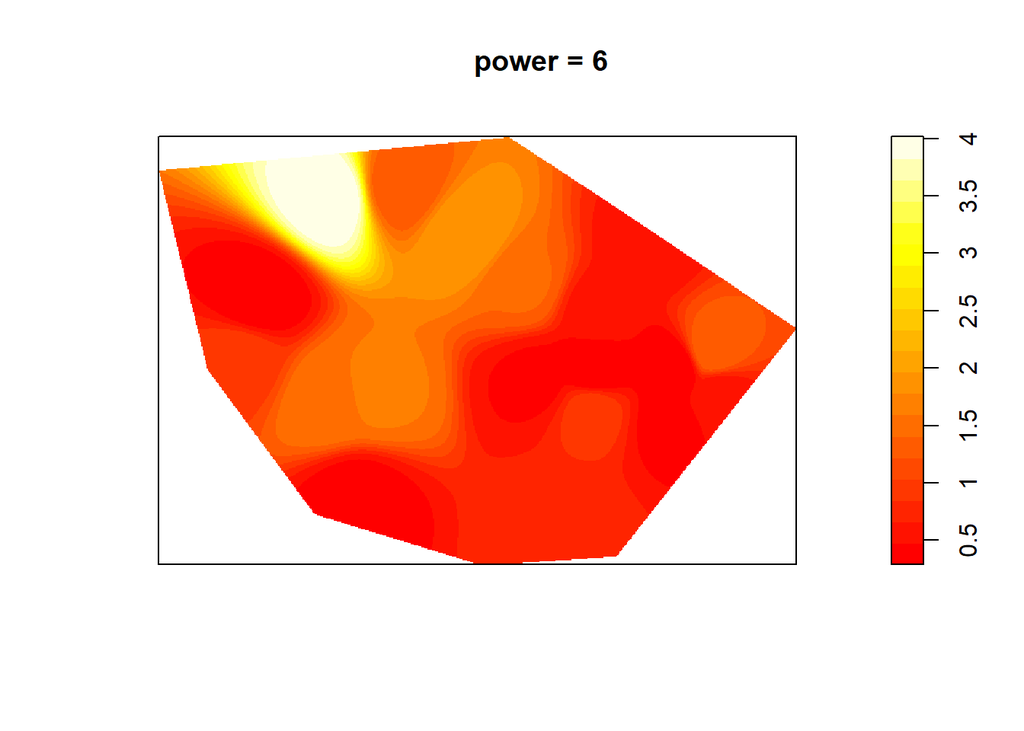

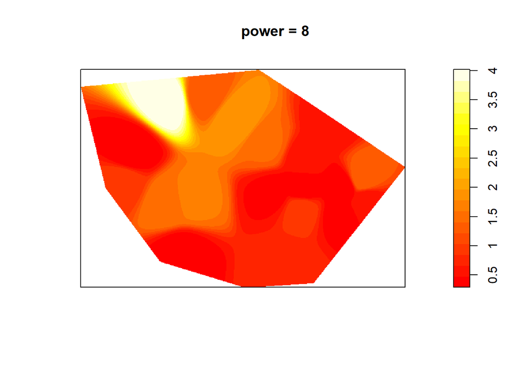

```
## The below plot is use the Mean Squared Error (mse) to compute the average squared difference between the powers and detect the optimal power
```

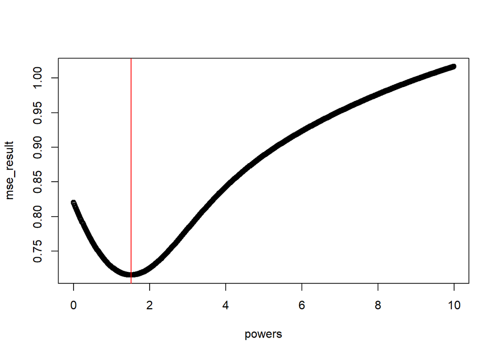

```
## The optimal power detected to be used is: 1.511
##
## However the function by default set the power to 2.
##
## You can change it by going to the src folder, and open rlc_sample_template.Rmd, (line 168) and change the 2 to 999 for optimal
##
## or
##
## any other number.
##
## The plot is your reference.
##
## You can change the number of cells generated inside the defined area for the IDW calculation. By default, it is 500.
##
## By default, IDW calculation assumes that the data point locations are fixed,
## that is, the standard error only takes into account the variability in the mark values,
## and not the variability due to randomness of the data point locations.
## Here is an example if we set IDW to estimate standard error of points.
```

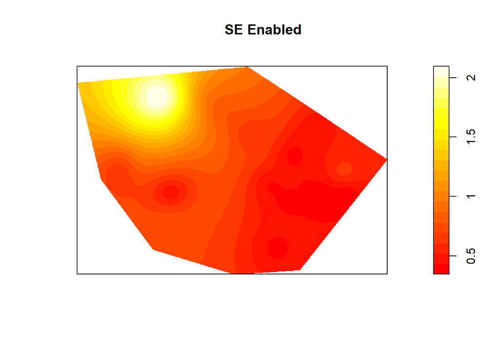

[interactive chart not shown]

## Estimation of Population

**Please note that these numbers are not the exact estimation of the population of the sampled area.** It is suggested to triangulate with other numbers such as the World Pop, etc.

```
## Estimated number of household for the total area: 674
##
## Estimated number of people for the total area: 2595
##
## Average number of people per household: 3.85
```